# Section 6: Custom PCE dataset generation

## Generating custom PCE datasets

Following datasets were used for [`PlacentaCellEnrich`](https://placentacellenrich.gdcb.iastate.edu) (`PCE`)

1. Vento-Tormo R *et al*.: scRNA-Seq data across 32 placental and decidual cells (built-in default dataset for [`PCE`].
2. [Castel *et al.,*](https://pubmed.ncbi.nlm.nih.gov/33238118/) datasets, using [Petropoulos *et al.,*](https://pubmed.ncbi.nlm.nih.gov/27062923/) and [Zhou *et al.,*](https://pubmed.ncbi.nlm.nih.gov/31435013/).
3. [Xiang *et. al.*](https://pubmed.ncbi.nlm.nih.gov/31830756/) dataset

## Prerequisites

R packages required for this section are loaded.

```r
setwd("~/github/BAPvsTrophoblast_Amnion")
library(tidyverse)
library(TissueEnrich)
library(R.utils)
```

## Download counts file

```r
zplink <-
  "https://iastate.box.com/shared/static/pb42m8gz4sgmlvzlxxcdk22ec1ke6z8a.gz"
download.file(zplink, "ZhouPetro_rawCounts_tpm.txt.gz")
gunzip("ZhouPetro_rawCounts_tpm.txt.gz")
xilink <-
  "https://iastate.box.com/shared/static/5jhfv20ljybj4isvwidzl4rd06ncvnfl.gz"
download.file(xilink, "combined_555_rawCounts_tpm.txt.gz")
gunzip("combined_555_rawCounts_tpm.txt.gz")
```

## Castel (Zhou + Petropoulos)

[Castel *et al.,*](https://pubmed.ncbi.nlm.nih.gov/33238118/) used the data from [Petropoulos *et al.,*](https://pubmed.ncbi.nlm.nih.gov/27062923/) and [Zhou *et al.,*](https://pubmed.ncbi.nlm.nih.gov/31435013/) in their analyses. We used the same data downloaded directly from their [BitBucket](https://gitlab.univ-nantes.fr/E137833T/Castel_et_al_2020) for generating custom dataset for performing enrichment analyses.

```r
cts.castel <-
  as.matrix(read.csv(
    "ZhouPetro_rawCounts_tpm.txt",
    sep = "\t",
    row.names = "Geneid"
  ))
md.castel <-
  read.csv(
    "assets/metadata_castel.tsv",
    sep = "\t",
    header = FALSE,
    row.names = 1
  )
mycts.t <- as.data.frame(t(cts.castel))
metadata <- md.castel
colnames(metadata) <- c("days", "celltypes")
metadata <- metadata[2]
merged.table <-
  merge(metadata, mycts.t, by = "row.names", all.x = TRUE)
merged.table <-
  merged.table %>% remove_rownames %>% column_to_rownames(var = "Row.names")
mycts.mean <- aggregate(. ~ celltypes, merged.table, mean)
ordered <-
  as.data.frame(t(
    mycts.mean %>% remove_rownames %>% column_to_rownames(var = "celltypes")
  ))
se <-
  SummarizedExperiment(
    assays = SimpleList(as.matrix(ordered)),
    rowData = row.names(ordered),
    colData = colnames(ordered)
  )
te.dataset.castel <- teGeneRetrieval(se)
saveRDS(te.dataset.castel, file = "te.dataset.castel.rds")
results.summary <- as.data.frame(assay(te.dataset.castel))
```

```r
# DISTRIBUTIONS ----
# Setting a custom ggplot2 function
# This function makes a pretty ggplot theme
# This function takes no arguments
# meaning that you always have just niwot_theme() and not niwot_theme(something else here)
# source: https://ourcodingclub.github.io/tutorials/dataviz-beautification/

theme_niwot <- function(){
  theme_bw() +
    theme(axis.text.y = element_text(size = 12),
          axis.text.x = element_text(angle = 45, vjust = 1, hjust=1, size = 12),
          axis.title = element_text(size = 14),
          axis.line.x = element_line(color="black"),
          axis.line.y = element_line(color="black"),
          panel.border = element_blank(),
          panel.grid.major.x = element_blank(),
          panel.grid.minor.x = element_blank(),
          panel.grid.minor.y = element_blank(),
          panel.grid.major.y = element_blank(),
          plot.margin = unit(c(1, 1, 1, 1), units = , "cm"),
          plot.title = element_text(size = 18, vjust = 1, hjust = 0),
          legend.text = element_text(size = 12),
          legend.title = element_blank(),
          legend.position = c(0.95, 0.15),
          legend.key = element_blank(),
          legend.background = element_rect(color = "black",
                                           fill = "transparent",
                                           size = 2, linetype = "blank"))
}
```

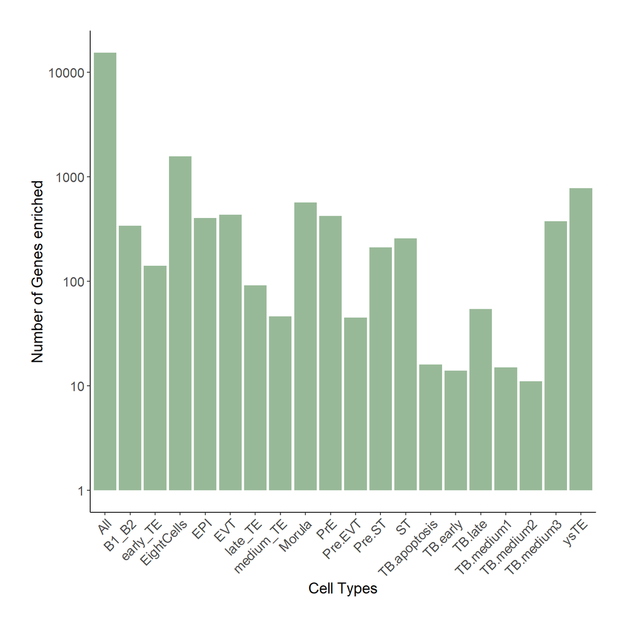

Fig 6.1: Castel Dataset tissue enrichement distribution

```r
ggplot(results.summary, aes(x = Tissue)) +
    stat_count(alpha = 0.6, fill = "palegreen4") +
  theme_niwot() +
  scale_y_log10() +
  xlab("Cell Types") +
  ylab("Number of Genes enriched")
```

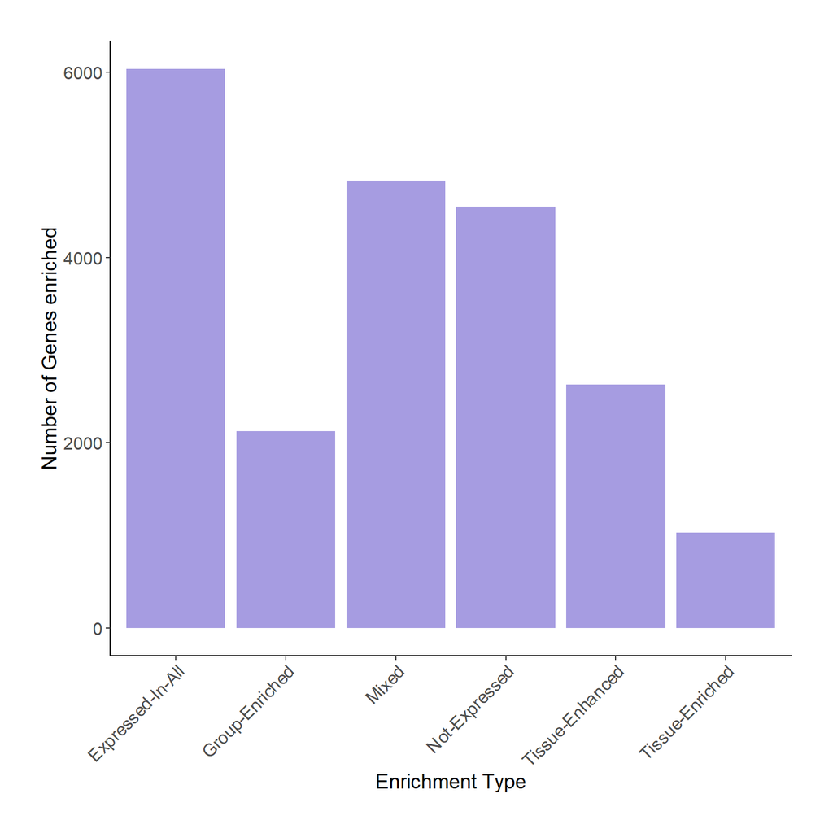

Fig 6.2: Castel Dataset tissue enrichement results

```r
ggplot(results.summary, aes(x = Group)) +
    stat_count(alpha = 0.6, fill = "slateblue") +
  theme_niwot() +
  xlab("Enrichment Type") +
  ylab("Number of Genes enriched")
```

## Xiang

[Xiang *et. al.*](https://pubmed.ncbi.nlm.nih.gov/31830756/) dataset was generated, after downloading the SRA datasets from NCBI BioProject# PRJNA562548.

### Download SRA datasets

```bash
while read a b; do
python3 enaBrowserTools-1.6/python3/enaDataGet.py \
  -f fastq \
  -as ~/.aspera_setting.ini \
  $a;
done < assets/PRJNA562548.txt
```

### Genome/annotation

```bash
wget ftp://ftp.ebi.ac.uk/pub/databases/gencode/Gencode_human/release_37/gencode.v37.primary_assembly.annotation.gtf.gz
wget ftp://ftp.ebi.ac.uk/pub/databases/gencode/Gencode_human/release_37/GRCh38.primary_assembly.genome.fa.gz
gunzip gencode.v37.primary_assembly.annotation.gtf.gz
gunzip GRCh38.primary_assembly.genome.fa.gz
```

### Mapping

Script to index (`star-index.sh`):

```bash
#!/bin/bash
module load star
GTF=gencode.v37.primary_assembly.annotation.gtf
FASTA=GRCh38.primary_assembly.genome.fa
STAR --runThreadN 36 \
     --runMode genomeGenerate \
     --genomeDir GRCh38 \
     --sjdbOverhang 100 \
     --sjdbGTFfile ${GTF} \
     --genomeFastaFiles ${FASTA}
```

Script to Map/Count (`star-map.sh`):

```bash
 #!/bin/bash
module load star
index=/work/LAS/geetu-lab/arnstrm/amnion-rnaseq/lo-etal/GRCh38
read1=$1
cpus=36
out=$(basename ${read1} | sed 's/.fastq.gz//g')
STAR \
--runThreadN 36 \
--genomeDir $index \
--outSAMtype BAM SortedByCoordinate \
--quantMode GeneCounts \
--outFilterScoreMinOverLread 0.3 \
--outFilterMatchNminOverLread 0.3 \
--outFileNamePrefix ${out}_ \
--readFilesCommand zcat \
--readFilesIn ${read1}
```

Prepare jobs:

```bash
find $(pwd) -name ".fastq.gz" > input.fofn
```

Slurm job script (`star.slurm`):

```bash
#!/bin/bash
#SBATCH --nodes=1
#SBATCH --exclusive
#SBATCH --time=8:00:00
#SBATCH --job-name=star
#SBATCH --output=nova-%x.%j.out
#SBATCH --error=nova-%x.%j.err
#SBATCH --mail-user=arnstrm@gmail.com
#SBATCH --mail-type=begin
#SBATCH --mail-type=end
IFS=$'\n' read -d '' -r -a LINES < input.fofn
LINE=${LINES[$SLURM_ARRAY_TASK_ID]}
echo -e "$(date +"%D  %r")\tthis command is ${LINE}"
./star-map.sh ${LINE}
```

Submit jobs:

```bash
sbatch --array=0-554 star.slurm
```

### Counts

```bash
for f in *_ReadsPerGene.out.tab; do
g=$(echo $f |sed 's/_ReadsPerGene.out.tab//g');
echo -e "AA_geneids\t$g" > ${g}_counts.txt;
tail -n +5 $f | cut -f1,4 >> ${g}_counts.txt;
done
join_files.sh *_counts.txt | grep -v "_counts.txt" | sort -k1,1 > counts-555.txt
# get geneids (protein coding only) from GTF file
gtf=gencode.v37.basic.annotation.gtf
awk '$3=="gene"' $gtf |\
  cut -f 9 |\
  awk '$4 ~ /protein_coding/ {print $2}'|\
  sed -e 's/";//g' -e sed 's/"//g' > gene.ids
#filter coutns to retain only counts for geneids
grep -Fw -f gene.ids counts-555.txt > combined_555_rawCounts.txt
```

### Generate TPM

From the raw counts, TPM table was generated using the raw counts. First `normalize.R` script was saved as follows:

```bash
#! /usr/bin/env Rscript
# load the module
# r-devtools
# r-tidyr
# r-dplyr
# module load r-devtools r-tidyr r-dplyr
## functions for rpkm and tpm
## from https://gist.github.com/slowkow/c6ab0348747f86e2748b#file-counts_to_tpm-r-L44
## from https://www.biostars.org/p/171766/
rpkm <- function(counts, lengths) {
  rate <- counts / lengths
  rate / sum(counts) * 1e9
}
tpm <- function(counts, lengths) {
  rate <- counts / lengths
  rate / sum(rate) * 1e6
}
## read table from featureCounts output
args <- commandArgs(T)
tag <- tools::file_path_sans_ext(args[1])
ftr.cnt <- read.table(args[1], sep="\t", stringsAsFactors=FALSE,
  header=TRUE)
library(dplyr)
library(tidyr)
ftr.rpkm <- ftr.cnt %>%
  gather(sample, cnt, 7:ncol(ftr.cnt)) %>%
  group_by(sample) %>%
  mutate(rpkm=rpkm(cnt, Length)) %>%
  select(-cnt) %>%
  spread(sample,rpkm)
write.table(ftr.rpkm, file=paste0(tag, "_rpkm.txt"), sep="\t", row.names=FALSE, quote=FALSE)
ftr.tpm <- ftr.cnt %>%
  gather(sample, cnt, 7:ncol(ftr.cnt)) %>%
  group_by(sample) %>%
  mutate(tpm=tpm(cnt, Length)) %>%
  select(-cnt) %>%
  spread(sample,tpm)
write.table(ftr.tpm, file=paste0(tag, "_tpm.txt"), sep="\t", row.names=FALSE, quote=FALSE)
```

second, the code was excuted as follows:

```bash
./normalize.R combined_555_rawCounts.txt
```

This generates two files: `combined_555_rawCounts_tpm.txt` and `combined_555_rawCounts_rpkm.txt`.

### Processing TPM

```r
cts.xiang <-
  as.matrix(read.csv(
    "combined_555_rawCounts_tpm.txt",
    sep = "\t",
    row.names = "Geneid"
  ))
md.xiang <-
  read.csv(
    "assets/metadata_555.txt",
    sep = "\t",
    header = FALSE,
    row.names = 1
  )
mycts.t <- as.data.frame(t(cts.xiang))
metadata <- md.xiang
colnames(metadata) <- c("days", "celltypes")
metadata <- metadata[2]
merged.table <- merge(metadata, mycts.t, by = "row.names", all.x = TRUE)
merged.table <-
  merged.table %>% remove_rownames %>% column_to_rownames(var = "Row.names")
mycts.mean <- aggregate(. ~ celltypes, merged.table, mean)
ordered <-
  as.data.frame(t(
    mycts.mean %>% remove_rownames %>% column_to_rownames(var = "celltypes")
  ))
se <-
  SummarizedExperiment(
    assays = SimpleList(as.matrix(ordered)),
    rowData = row.names(ordered),
    colData = colnames(ordered)
  )
te.dataset.xiang <-
  teGeneRetrieval(
    se,
    foldChangeThreshold = 5,
    maxNumberOfTissues = 6,
    expressedGeneThreshold = 1
  )
saveRDS(te.dataset.xiang, file = "te.dataset.xiang.rds")
results.summary <- as.data.frame(assay(te.dataset.xiang))
```

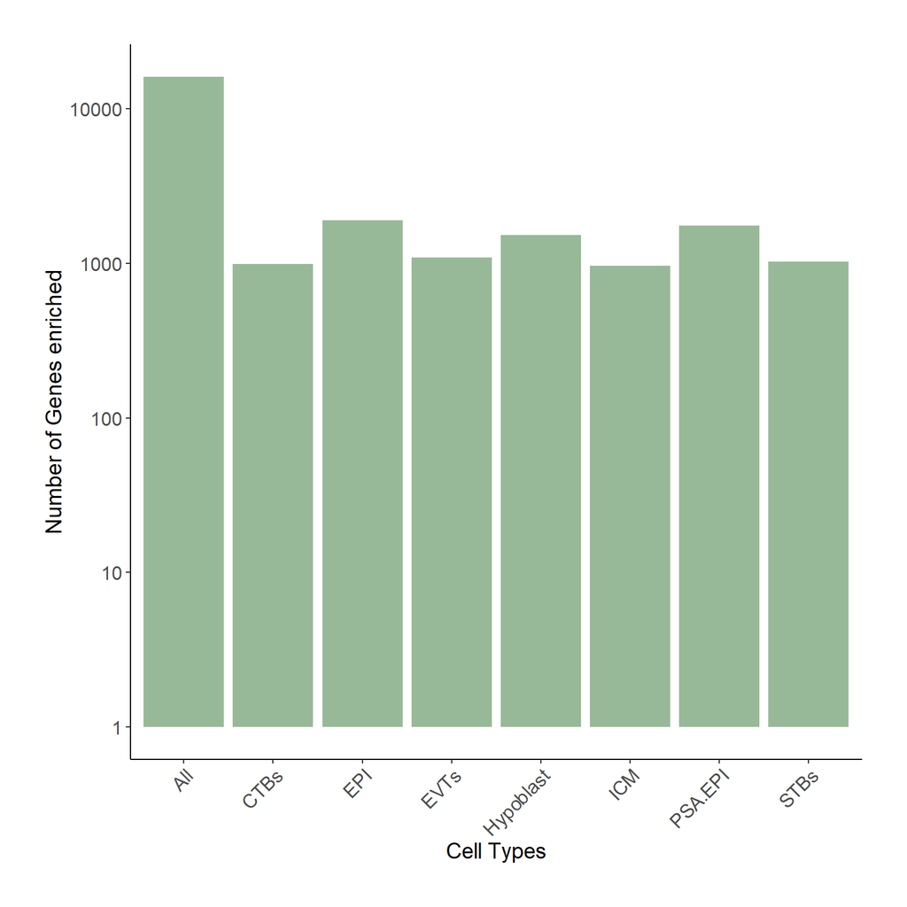

Fig X.1: Xiang Dataset tissue enrichement distribution

```r
ggplot(results.summary, aes(x = Tissue)) +
    stat_count(alpha = 0.6, fill = "palegreen4") +
  theme_niwot() +
  scale_y_log10() +
  xlab("Cell Types") +
  ylab("Number of Genes enriched")
```

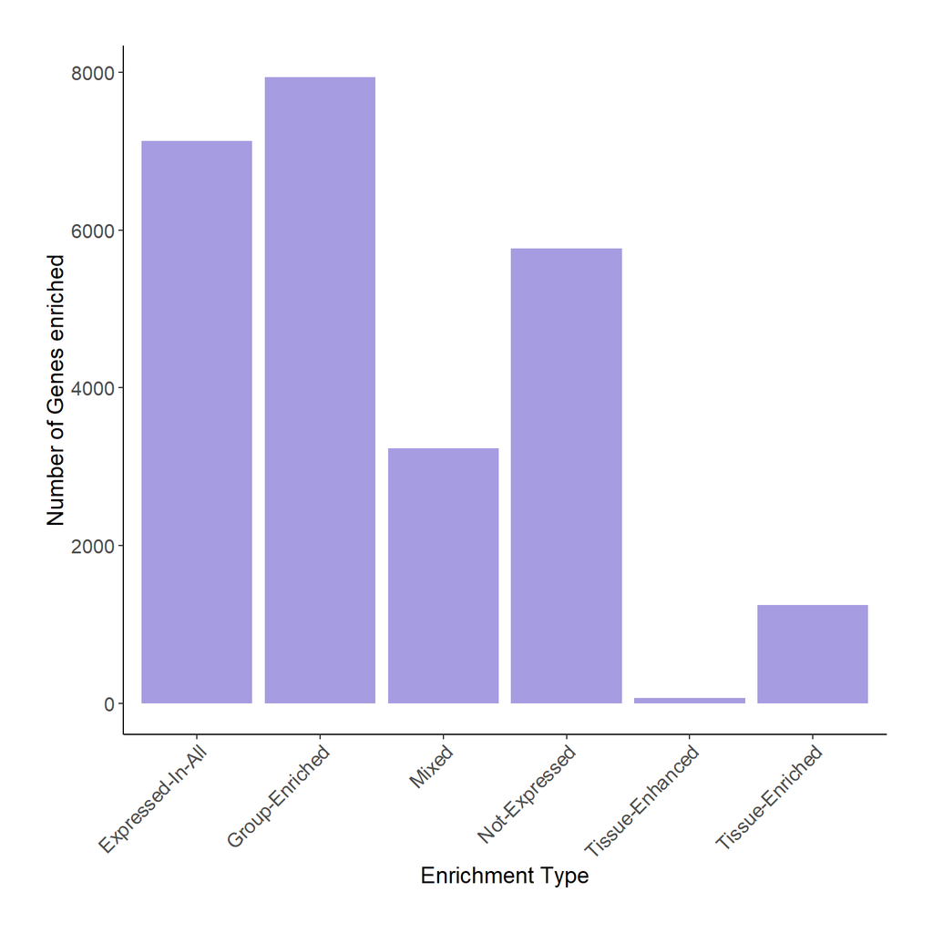

Fig X.2: Xiang Dataset tissue enrichement results

```r
ggplot(results.summary, aes(x = Group)) +
    stat_count(alpha = 0.6, fill = "slateblue") +
  theme_niwot() +
  xlab("Enrichment Type") +
  ylab("Number of Genes enriched")
```

## Save Image file

```r
save.image(file = "customPCE_data.RData")
```